# Rep_Res_Proj

Andrew Crena

2023-03-18

# Reproducible Research Assignment

## Analyzing data from activity trackers (steps in 5 min intervals)

## First, we will load the data after loading the necesssary packages

```r
library(ggplot2)
library(scales)
library(Hmisc)
if(!file.exists('activity.csv')){unzip('activity.zip')
}
dataSet <- read.csv('activity.csv')
str(dataSet)
```

```
## 'data.frame':    17568 obs. of  3 variables:
##  $ steps   : int  NA NA NA NA NA NA NA NA NA NA ...
##  $ date    : chr  "2012-10-01" "2012-10-01" "2012-10-01" "2012-10-01" ...
##  $ interval: int  0 5 10 15 20 25 30 35 40 45 ...
```

## Now, we will find the mean number of steps taken per day.

find total number of steps taken per day

```r
total_steps <- tapply(dataSet$steps, dataSet$date, sum, na.rm=TRUE)
```

Making a Histogram of the data

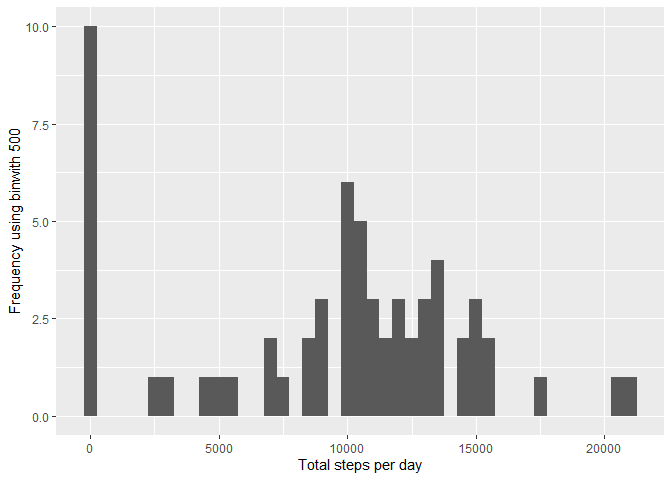

```r
qplot(total_steps, xlab='Total steps per day',
      ylab='Frequency using binwith 500', binwidth=500)
```

Calculate the daily mean and median of steps

```r
dailymeansteps <- mean(total_steps)
dailymediansteps <- median(total_steps)
```

Mean = 9354.23, Median = 10395

## Observing the daily activity pattern through a time series plot

## define daily activity

```r
avgdailyact <- aggregate(x=list(meanSteps=dataSet$steps),
                         by=list(interval=dataSet$interval),
                         FUN=mean, na.rm=TRUE)
```

Next, create a time series plot, witj 5-minute intervals (x-axis), and the average number of steps taken, averaged acorss all of the days

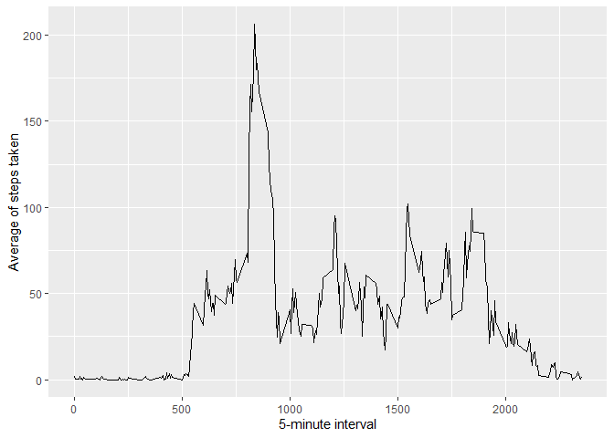

```r
ggplot(data=avgdailyact, aes(x=interval, y=meanSteps)) + geom_line() +
     xlab("5-minute interval") + ylab("Average of steps taken")
```

```r
moststeps <- which.max(avgdailyact$meanSteps)
timemoststeps <-  gsub("([0-9]{1,2})([0-9]{2})", "\\1:\\2",
                       avgdailyact[moststeps,'interval'])
```

## Time to address the missing values!

First, we will calculate the number of NAs

```r
missvals <- length(which(is.na(dataSet$steps)))
```

Missing Values: 2304

We will create a histogram, then calculate the median and mean. By comparing these results to the first part of this assignment when we did not address, the missing values, we can observe the effect of filling NAs with mean and median

```r
DSI <- dataSet
DSI$steps <- impute(dataSet$steps, fun=mean)
```

Creating Histogram…

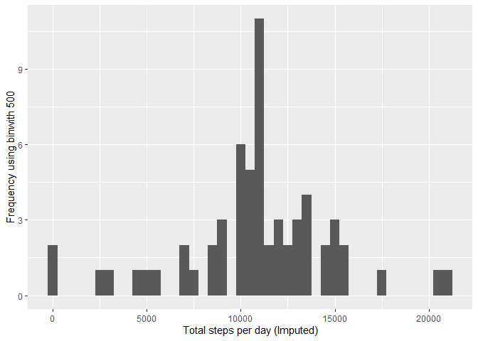

```r
I <- tapply(DSI$steps, DSI$date, sum)
qplot(I, xlab='Total steps per day (Imputed)',
      ylab='Frequency using binwith 500', binwidth=500)
```

Now, we will calculate the mean and median.c

```r
dMeanImp <- mean(I)
dMedImp <- median(I)
```

Mean = 10766.19, Median = 10766.19

## Lastly, we want to observe the difference, if any, in activity patterns

## between weekends and weekdays. We will be using a panel plot to visualize

## the potential differences. Let’s check it out!

First, let’s create a new factor in the dataset, separating weekdays & weekends

```r
DSI$dateType <-  ifelse(as.POSIXlt(DSI$date)$wday %in% c(0,6),
                        'weekend', 'weekday')
```

Next, let’s make the panel plot (comparing two time-series plots)using the facet aspect of ggplot

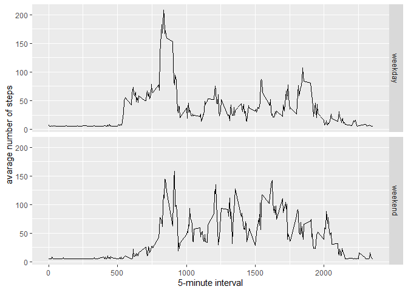

```r
AVG <- aggregate(steps ~ interval + dateType, data=DSI, mean)
ggplot(AVG, aes(interval, steps)) + geom_line() + facet_grid(dateType ~ .) + xlab("5-minute interval") + ylab("avarage number of steps")
```